# Assignment 12: Predictive Modeling - Part 3

*How to do it?*:

- Open the Rmarkdown file of this assignment (link) in Rstudio.
- Right under each **question**, insert a code chunk (you can use the hotkey `Ctrl + Alt + I` to add a code chunk) and code the solution for the question.
- `Knit` the rmarkdown file (hotkey: `Ctrl + Alt + K`) to export an html.
- Publish the html file to your Githiub Page.

*Submission*: Submit the link on Github of the assignment to Blackboard.

1. Use the `PimaIndiansDiabetes` dataset. Use 15% data for testing. Use cross-validation with 7 folds to tune random forest `(method='ranger')`. What are the parameters that produce the greatest accuracy? What is the testing accuracy.

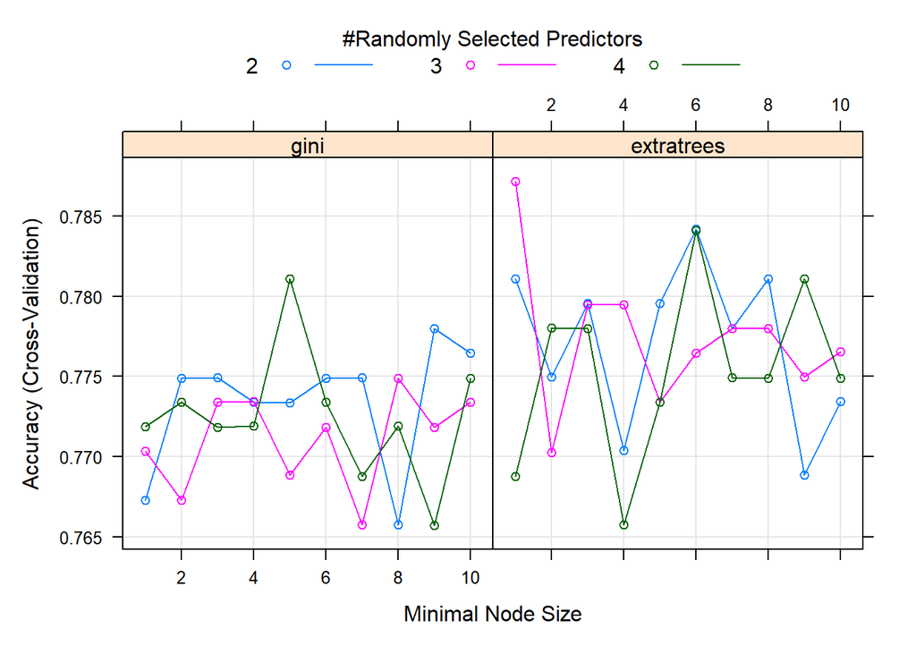

```r
library(mlbench)
library(tidyverse)
library(caret)
data(PimaIndiansDiabetes)
df <- tibble(PimaIndiansDiabetes)

df = drop_na(df)
splitIndex <- createDataPartition(df$diabetes, p = .85,
                                  list = FALSE)
df_train <- df[ splitIndex,]
df_test <- df[-splitIndex,]

trControl = trainControl(method = "cv",
                         number = 7)
tuneGrid = expand.grid(mtry = 2:4,
                       splitrule = c('gini', 'extratrees'),
                       min.node.size = c(1:10))
forest_ranger <- train(diabetes~., data=df_train,
                    method = "ranger",
                    trControl = trControl,
                    tuneGrid = tuneGrid)
plot(forest_ranger)
```

```r
pred <- predict(forest_ranger, df_test)
cm <- confusionMatrix(data = pred, reference = df_test$diabetes, positive = "pos")
cm$overall[1]
```

```
## Accuracy
## 0.773913
```

2. Use the `PimaIndiansDiabetes` dataset. Go to https://topepo.github.io/caret/available-models.html and pick a classification model. Tune the classification model using cross-validation of 7 folds.

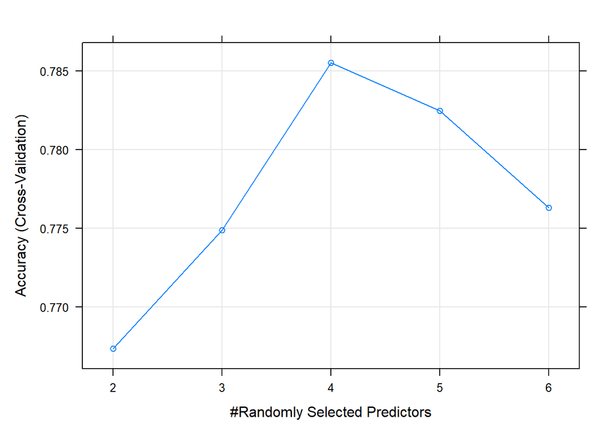

```r
trControl = trainControl(method = "cv",
                         number = 7)
tuneGrid = expand.grid(mtry = c(2:6))
cforest <- train(diabetes~., data=df_train,
                    method = "cforest",
                    trControl = trControl,
                    tuneGrid = tuneGrid)
plot(cforest)
```

```r
pred <- predict(cforest, df_test)
cm <- confusionMatrix(data = pred, reference = df_test$diabetes, positive = "pos")
cm$overall[1]
```

```
##  Accuracy
## 0.7391304
```

3. Use the `PimaIndiansDiabetes` dataset. Pick three models at [this link](https://topepo.github.io/caret/available-models.html) to compare using 7-fold cross validation method. Evaluate the accuracy of the final model on the test data. What is the best model?

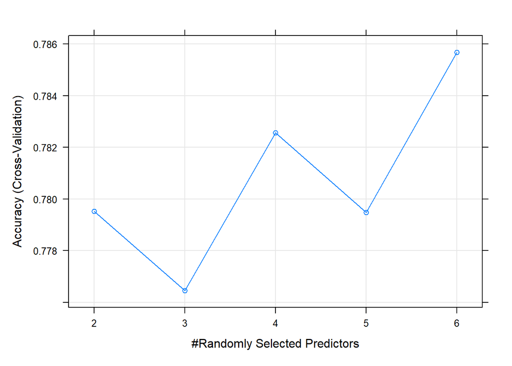

```r
trControl = trainControl(method = "cv",
                         number = 7)
tuneGrid = expand.grid(mtry = c(2:6))
parRF <- train(diabetes~., data=df_train,
                    method = "parRF",
                    trControl = trControl,
                    tuneGrid = tuneGrid)
plot(parRF)
```

```r
pred1 <- predict(parRF, df_test)
cm1 <- confusionMatrix(data = pred1, reference = df_test$diabetes, positive = "pos")
cm1$overall[1]
```

```
##  Accuracy
## 0.7652174
```

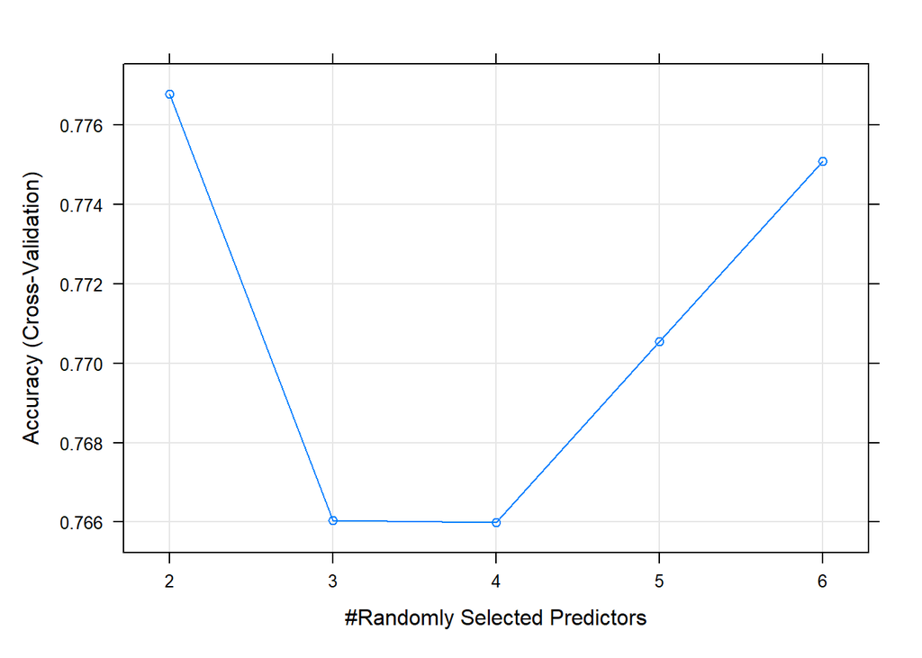

```r
trControl = trainControl(method = "cv",
                         number = 7)
tuneGrid = expand.grid(mtry = c(2:6))
rf <- train(diabetes~., data=df_train,
                    method = "rf",
                    trControl = trControl,
                    tuneGrid = tuneGrid)
plot(rf)
```

```r
pred2 <- predict(rf, df_test)
cm2 <- confusionMatrix(data = pred2, reference = df_test$diabetes, positive = "pos")
cm2$overall[1]
```

```
##  Accuracy
## 0.7478261
```

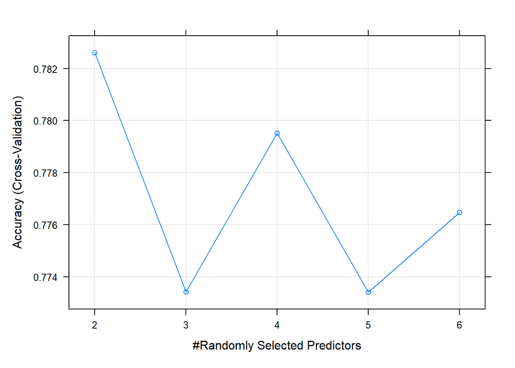

```r
trControl = trainControl(method = "cv",
                         number = 7)
tuneGrid = expand.grid(mtry = c(2:6))
wsrf <- train(diabetes~., data=df_train,
                    method = "wsrf",
                    trControl = trControl,
                    tuneGrid = tuneGrid)
plot(wsrf)
```

```r
pred3 <- predict(wsrf, df_test)
cm3 <- confusionMatrix(data = pred3, reference = df_test$diabetes, positive = "pos")
cm3$overall[1]
```

```
##  Accuracy
## 0.7391304
```